# MrBeast Youtube Engagement Analytics!!!

# Finding duplicates

Lets see if there are any duplicates in the data set, because I used two different endpoint functions: one for normal videos and one for playlist videos.

```r
duplicates <- duplicated(df$title)
total_duplicates <- sum(duplicates)
total_duplicates
```

```
## [1] 245
```

- whoa! Around 45 percent of the videos are duplicates.
- It is because I used two functions to pull videos from the API: non_playlist_videos and playlist_videos
- Most of the videos returned by these two methods are same but YouTube gives it different video Ids.
- However, there were some videos there are only returned in one category and that is why I used two functions.

Lets drop them.

```r
df <- df[!duplicated(df$title),]
paste("Number of rows:",nrow(df))
```

```
## [1] "Number of rows: 292"
```

Let’s now convert the column “pubishedAt” column into a data-time format yyyy-mm-dd and create another column for year to do aggregate analysis.

```r
df <- df %>% mutate(publishedAt = as.POSIXct(publishedAt, format = "%Y-%m-%dT%H:%M:%SZ", tz = "UTC")) %>% mutate(publishedAt = format(publishedAt, format = "%Y-%m-%d"),)
df$year <- format(as.Date(df$publishedAt), format="%Y")
```

```r
head(df)
```

```
##   X     videoId                                             title publishedAt
## 1 0 jdMNoQE3mIQ                          I Survived A Plane Crash  2022-08-20
## 2 1 FD-0KG-h2-c Gordon Ramsay Tries Most Expensive Chocolate Bar!  2022-11-19
## 3 2 se50viFJ0AQ            Would You Fly To Paris For A Baguette?  2022-12-08
## 4 3 1WEAJ-DFkHE                      $1 vs $500,000 Plane Ticket!  2023-04-01
## 5 4 h5NvTTOlOtI                    Hydraulic Press Vs Lamborghini  2022-12-10
## 6 5 Y0cBiGUuB1Y                 I Sent a Subscriber to Disneyland  2023-03-30
##   viewCount likeCount commentCount duration duration_in_seconds year
## 1 103245270   3184622        77705  PT8M14S                 494 2022
## 2 184170928  10937177        25538    PT41S                  41 2022
## 3 667645634  32420533        67884    PT48S                  48 2022
## 4 115277739   4347449       128145 PT12M20S                 740 2023
## 5 145757315   4867123       131757 PT10M25S                 625 2022
## 6  97208496   6993068        24852    PT27S                  27 2023
```

Now, lets also remove all of his 2023 videos because it has just been 3 months and it takes some time for a video to reach its actual engagement statistics.

```r
df %>% filter(year==2023) %>% select(title)
```

```
##                                       title
## 1              $1 vs $500,000 Plane Ticket!
## 2         I Sent a Subscriber to Disneyland
## 3 1,000 Blind People See For The First Time
## 4  I Paid A Real Assassin To Try To Kill Me
## 5            Do Men Lie About Their Height?
```

Finally, we remove these 5 videos and summarize the dataframe below.

```r
df <- df %>% filter(year<2023)
paste("We will do analysis on",nrow(df),"videos.")
```

```
## [1] "We will do analysis on 287 videos."
```

## Summary

```r
summary(df)
```

```
##        X           videoId             title           publishedAt
##  Min.   :  0.0   Length:287         Length:287         Length:287
##  1st Qu.: 76.5   Class :character   Class :character   Class :character
##  Median :144.0   Mode  :character   Mode  :character   Mode  :character
##  Mean   :136.1
##  3rd Qu.:197.5
##  Max.   :257.0
##
##    viewCount           likeCount         commentCount      duration
##  Min.   :    30003   Min.   :     728   Min.   :   138   Length:287
##  1st Qu.: 23691317   1st Qu.:  614097   1st Qu.: 30871   Class :character
##  Median : 67936452   Median : 1692212   Median : 65674   Mode  :character
##  Mean   : 81334964   Mean   : 2323042   Mean   : 76505
##  3rd Qu.:124894072   3rd Qu.: 3145162   3rd Qu.:102688
##  Max.   :667645634   Max.   :32420533   Max.   :746913
##                                         NA's   :1
##  duration_in_seconds     year
##  Min.   :   31.0     Length:287
##  1st Qu.:  563.0     Class :character
##  Median :  790.0     Mode  :character
##  Mean   : 1703.0
##  3rd Qu.:  924.5
##  Max.   :82838.0
##
```

# Top Five watched videos

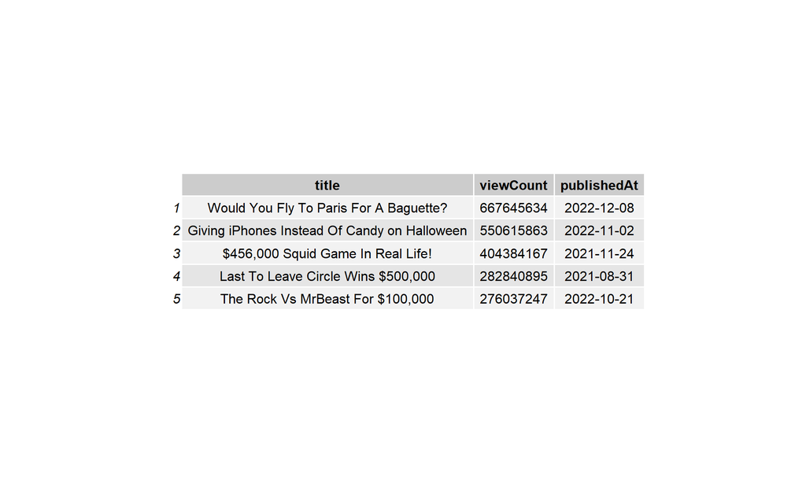

```r
top_five = df %>% slice_max(viewCount,n=5) %>% select(title,viewCount,publishedAt)
grid.table(top_five)
```

# Least Five watched videos

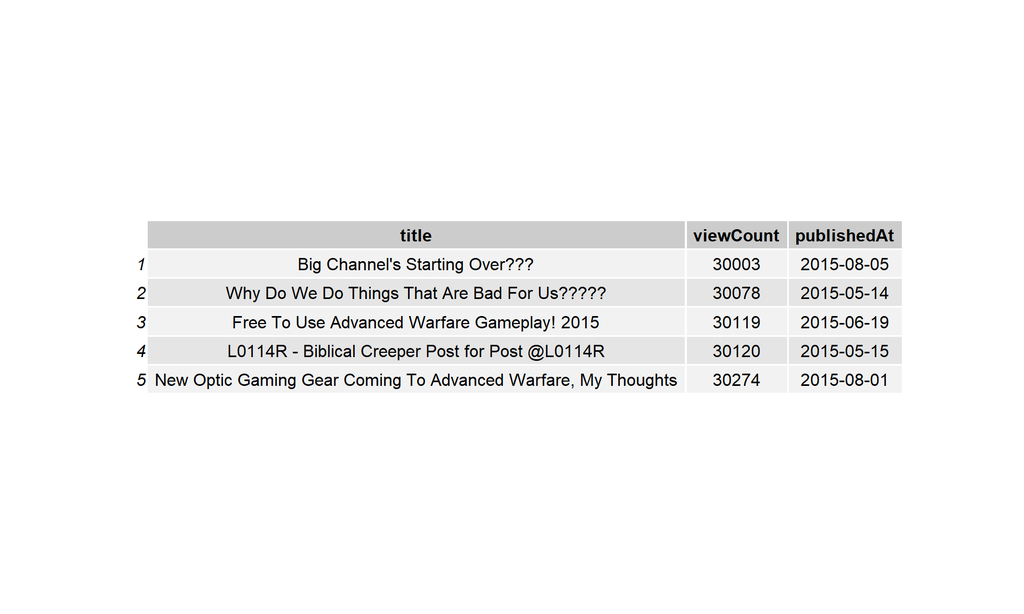

```r
least_five = df %>% slice_min(viewCount,n=5) %>% select(title,viewCount,publishedAt)
grid.table(least_five)
```

# Average Views over time

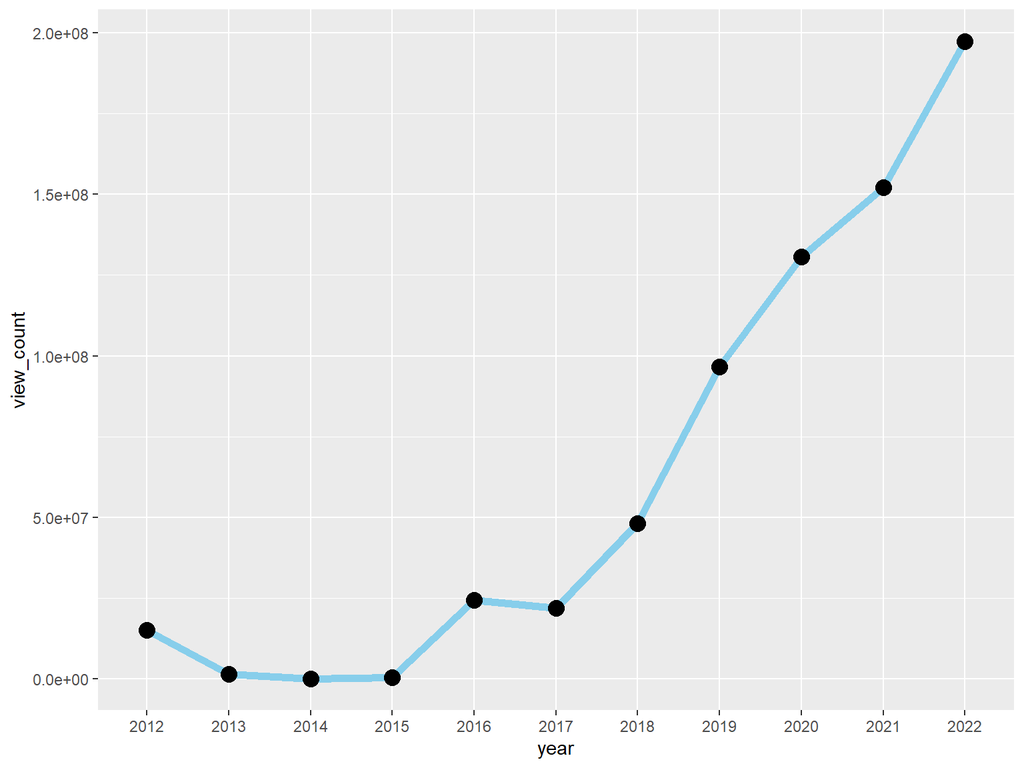

```r
ggplot(df %>% group_by(year) %>% mutate(view_count=mean(viewCount)), aes(x=year,y=view_count))+ geom_line(group=1,color='skyblue',size=2) + geom_point(size=4)
```

# Average Like Count over time

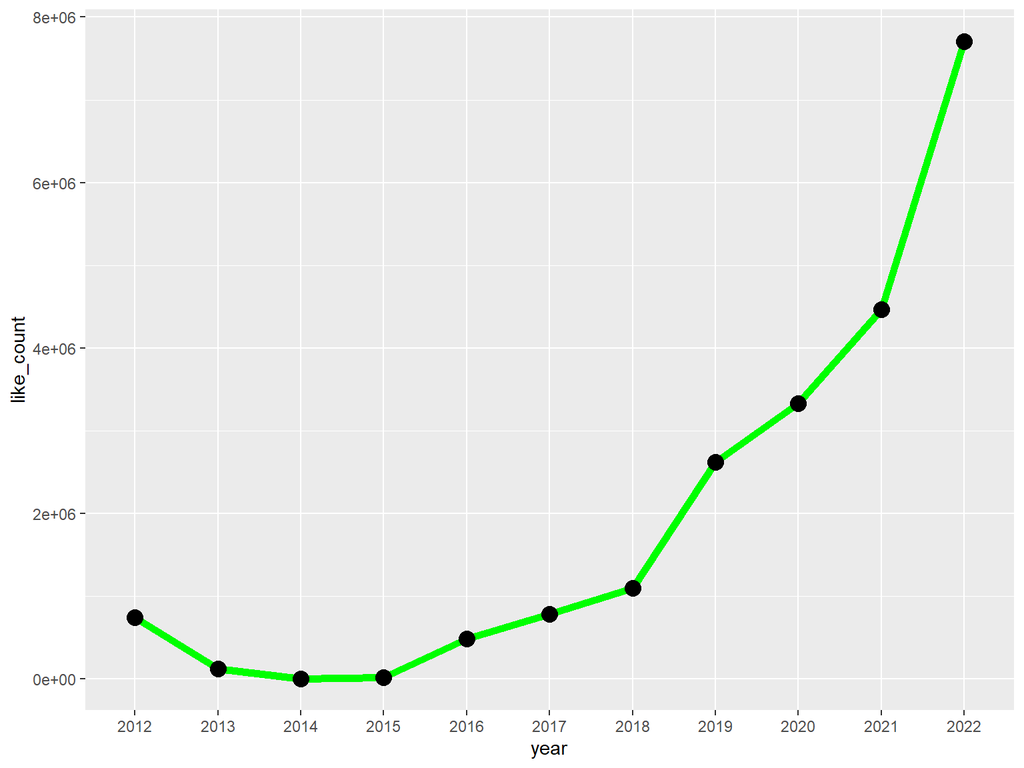

```r
ggplot(df %>% group_by(year) %>% mutate(like_count=mean(likeCount)), aes(x=year,y=like_count))+ geom_line(group=1,color='green',size=2) + geom_point(size=4)
```

# Videos by Year

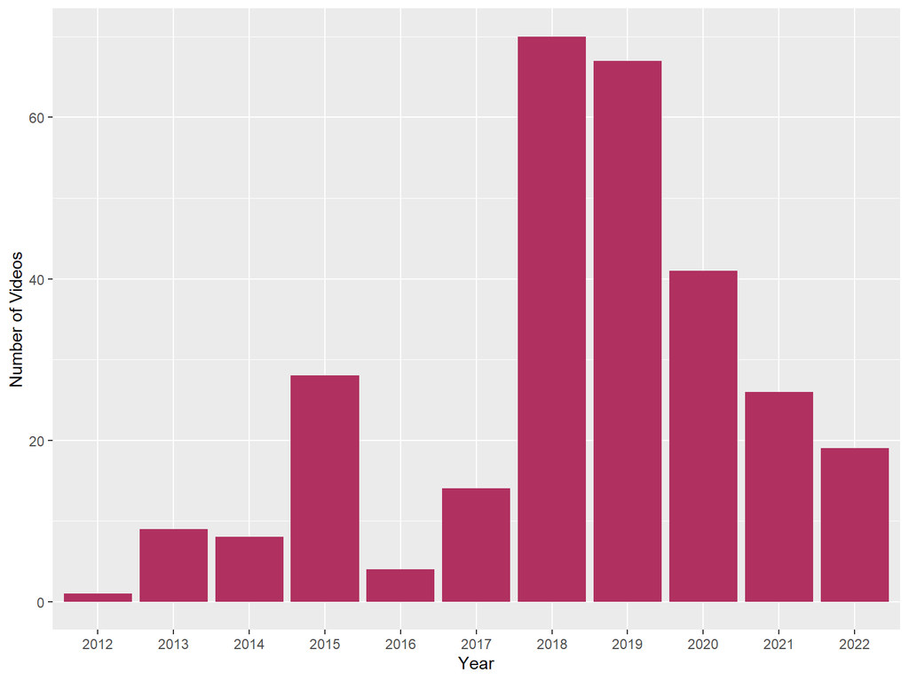

```r
ggplot(df) + geom_histogram(aes(x=year),stat="count",fill="maroon") + labs(x="Year", y = "Number of Videos")
```

# Videos by Month

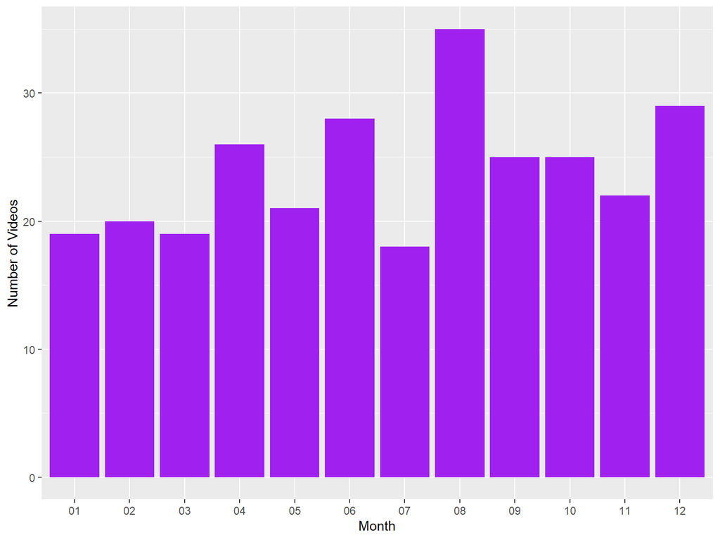

```r
ggplot(df, aes(x=format(as.Date(df$publishedAt), format="%m"))) + geom_bar(stat='count',fill="purple") + labs(x="Month", y = "Number of Videos")
```

# Is Mr Beast making longer videos now than before? Lets find out…

First,lets convert duration into minutes because seconds don’t make sense.

```r
df <- df %>% mutate(dur_in_min=round(duration_in_seconds/60,2))
```

Now, before me plot duration distributions for each year, lets plot a general duration distribution to find out outliers and remove them, because I know some Mr Beast Videos are hours long!!!

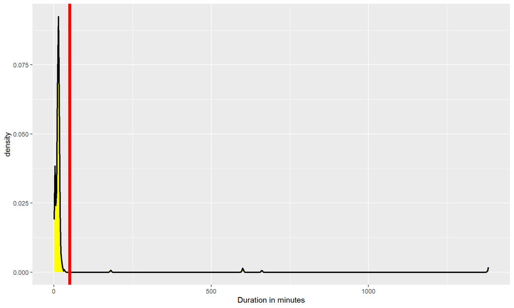

[figure not shown]

```r
ggplot(df, aes(x=dur_in_min)) + geom_density(fill="yellow",size=1) + labs(x="Duration in minutes") + geom_vline(xintercept = 50,size=2,color="red")
```

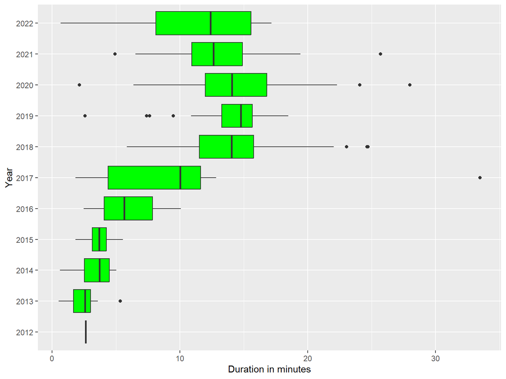

```r
ggplot(df %>% filter(dur_in_min<60),aes(y=year,x=dur_in_min)) + geom_boxplot(fill='green') + labs(x="Duration in minutes",y="Year")
```

Well, the general trend is that videos have gotten longer over time.

# Does duration affect like count?

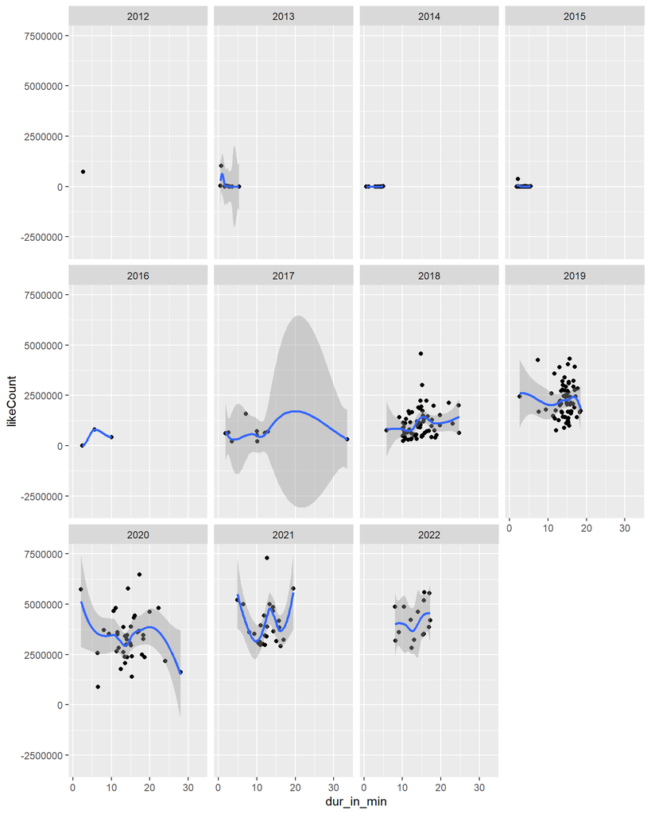

[figure not shown]

```r
ggplot(df %>% filter(dur_in_min<=60 & likeCount <= 10000000), aes(x = dur_in_min, y = likeCount)) + geom_point() + geom_smooth() + facet_wrap(vars(year))
```

## Like to View Ratio

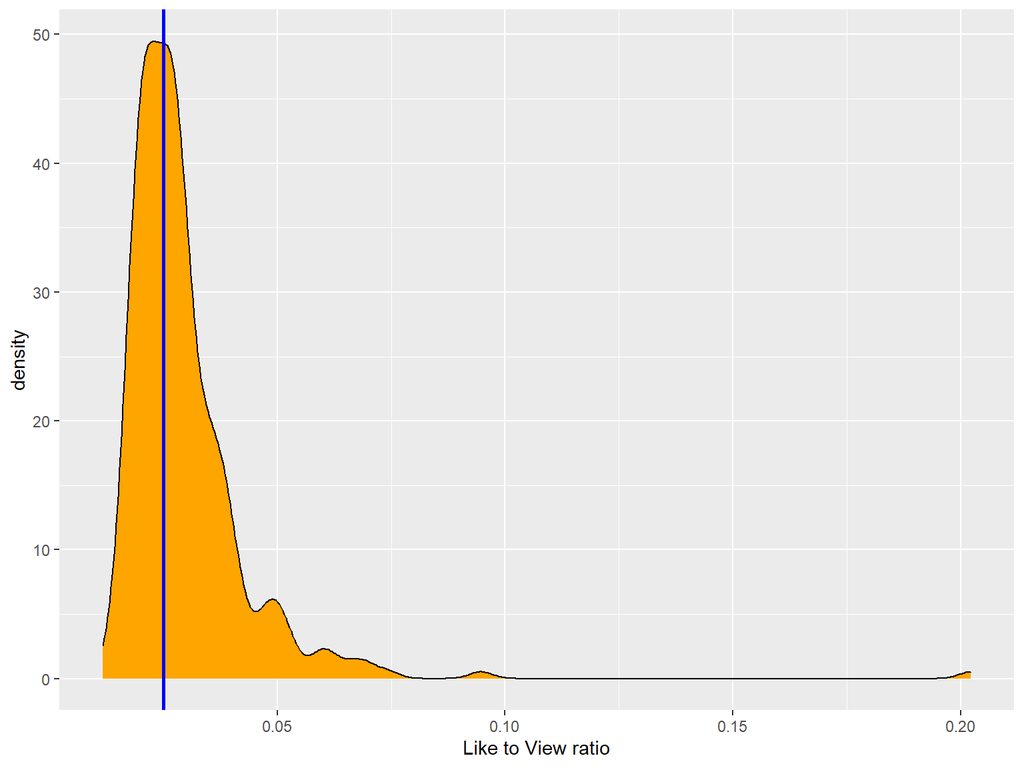

```r
ggplot(df, aes(x = df$likeCount/df$viewCount)) + geom_density(fill="orange") + labs(x= "Like to View ratio") +geom_vline(xintercept = 0.025,size=1,color="blue")
```

For every 2.5 people who like the video, there are 100 people who watch the video.

## Comment to Like Ratio

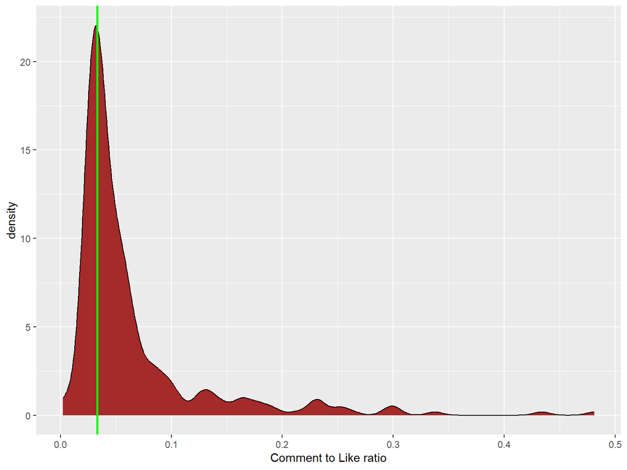

```r
ggplot(df, aes(x = df$commentCount/df$likeCount)) + geom_density(fill="brown") + geom_vline(xintercept = 0.033,size=1,color=
'green') + labs(x= "Comment to Like ratio")
```

For every 3.3 people who comment on this video, 100 people like the video.

# Have these ratios changed over time?

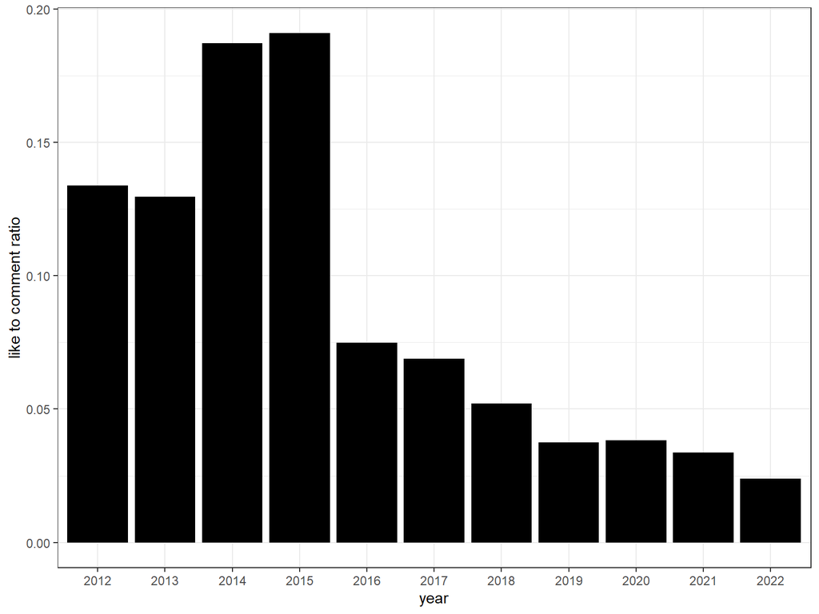

```r
ggplot(df, aes(x=year, y=commentCount/likeCount)) + geom_bar(stat='summary',fun="mean",fill="black") + labs(y="like to comment ratio",x="year") + theme_bw()
```

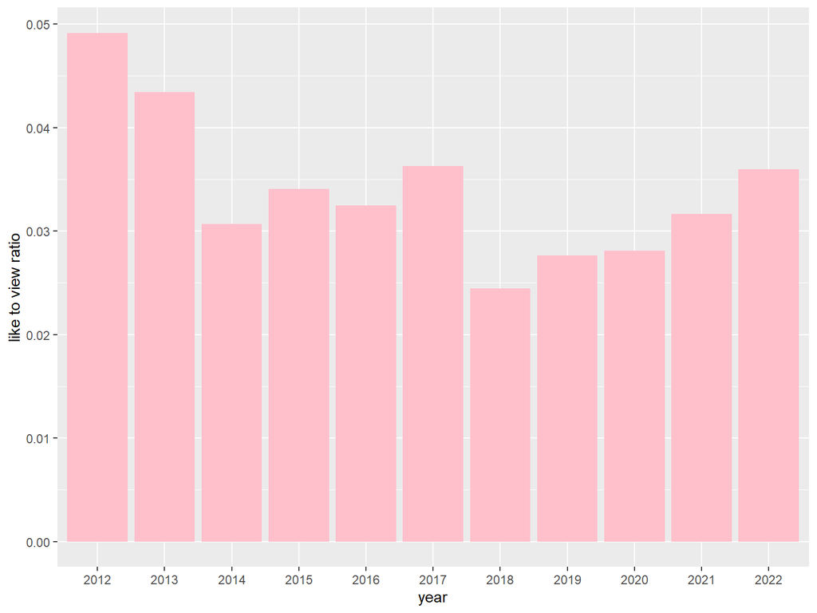

```r
ggplot(df, aes(x=year, y=df$likeCount/df$viewCount)) + geom_bar(stat='summary',fun="mean",fill="pink") + labs(y="like to view ratio")
```

On way to assess the success of a video is by user engagement turnover. In English, how higher were the above metrics. Now let’s out the five best videos in terms of like to ratio ratio.

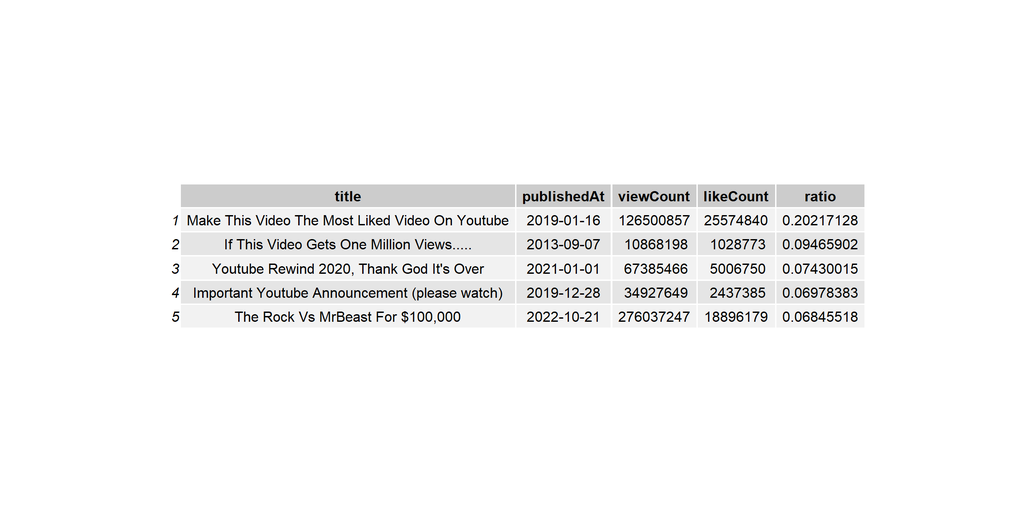

```r
grid.table(df %>% mutate(ratio=likeCount/viewCount) %>%  slice_max(ratio, n=5)  %>% select(title,publishedAt,viewCount,likeCount,ratio) %>% arrange(desc(ratio)))
```

#Moving Averages

```r
df <- df %>% arrange(as.Date(publishedAt)) %>%  mutate(view_ma_5 = rollapply(viewCount, width = 5, FUN = mean, fill = NA, align = "right"))
df <- df %>% arrange(as.Date(publishedAt)) %>%  mutate(like_ma_5 = rollapply(likeCount, width = 5, FUN = mean, fill = NA, align = "right"))
```

## View Count Moving avearge

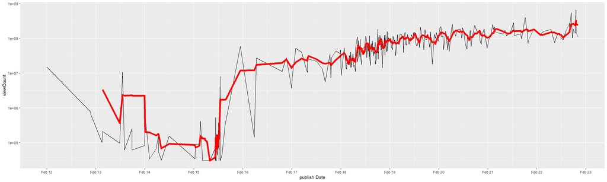

```r
ggplot(df, aes(x=as.Date(publishedAt))) + geom_line(aes(y=viewCount,group=1)) + geom_line(aes(y=view_ma_5,group=1),color="red",size=2) + scale_x_date(breaks = seq(as.Date("2012-02-20"), as.Date("2023-04-01"), by = "1 year"),
date_labels = "%b %y") + labs(x="publish Date") + scale_y_log10()
```

## Like Count Moving average

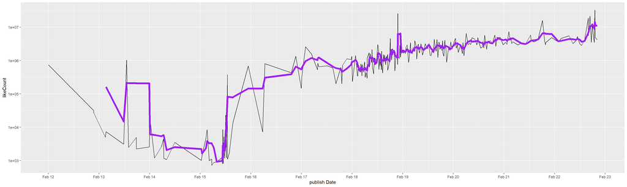

```r
ggplot(df, aes(x=as.Date(publishedAt))) + geom_line(aes(y=likeCount,group=1)) + geom_line(aes(y=like_ma_5,group=1),color="purple",size=2) + scale_x_date(breaks = seq(as.Date("2012-02-20"), as.Date("2023-04-01"), by = "1 year"),
date_labels = "%b %y") + labs(x="publish Date") + scale_y_log10()
```

# Titles and Descriptions

Lets know analyze what kind of vocabulary does Mr Beast use in his title and video descriptions? Are they catchy? Do they follow a certain pattern?

```r
# Cleaning the title column, converting it into corpus and making a frequency table
titles = df$title
docs <- Corpus(VectorSource(titles))
docs <- docs %>%
  tm_map(removeNumbers) %>%
  tm_map(removePunctuation) %>%
  tm_map(stripWhitespace)
docs <- tm_map(docs, content_transformer(tolower))
docs <- tm_map(docs, removeWords, stopwords("english"))
dtm <- TermDocumentMatrix(docs)
matrix <- as.matrix(dtm)
words <- sort(rowSums(matrix),decreasing=TRUE)
title_df <- data.frame(word = names(words),freq=words)
```

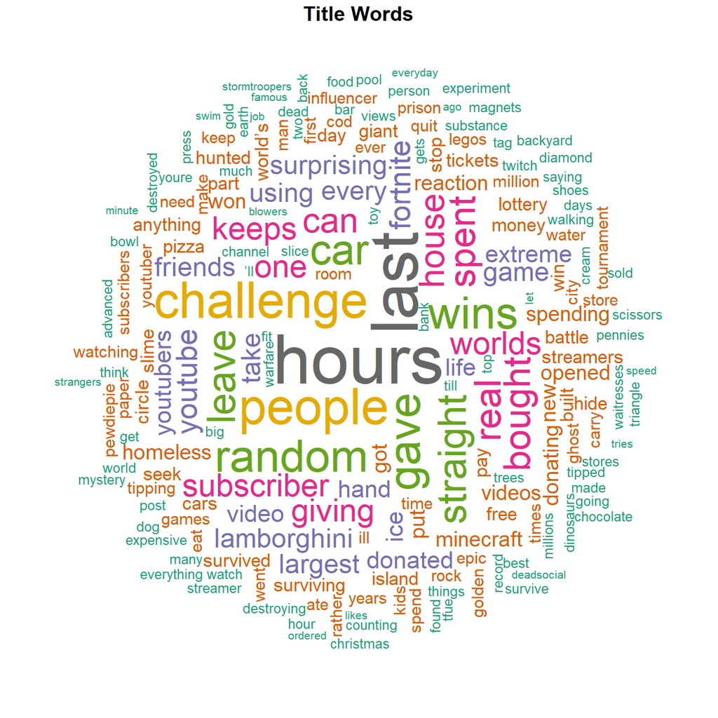

```r
set.seed(123)
wordcloud(words = title_df$word, freq = title_df$freq, min.freq = 1,max.words=200, random.order=FALSE, rot.per=0.35,colors=brewer.pal(8, "Dark2"))
title("Title Words", line = -1, outer = TRUE)
```

Words like “challenge”,“Last”,“Free”,“Random”,“Wins” do attract people.

```r
# Cleaning the title column, converting it into corpus and making a frequency table
descriptions = raw_df$description
descriptions = gsub("http[[:alnum:][:punct:]]*", "", descriptions)
descriptions = gsub('[^[:alnum:] ]','',descriptions)
docs <- Corpus(VectorSource(descriptions))
docs <- docs %>%
  tm_map(removeNumbers) %>%
  tm_map(removePunctuation) %>%
  tm_map(stripWhitespace)
docs <- tm_map(docs, content_transformer(tolower))
docs <- tm_map(docs, removeWords, stopwords("english"))
dtm <- TermDocumentMatrix(docs)
matrix <- as.matrix(dtm)
words <- sort(rowSums(matrix),decreasing=TRUE)
descriptions_df <- data.frame(word = names(words),freq=words)
```

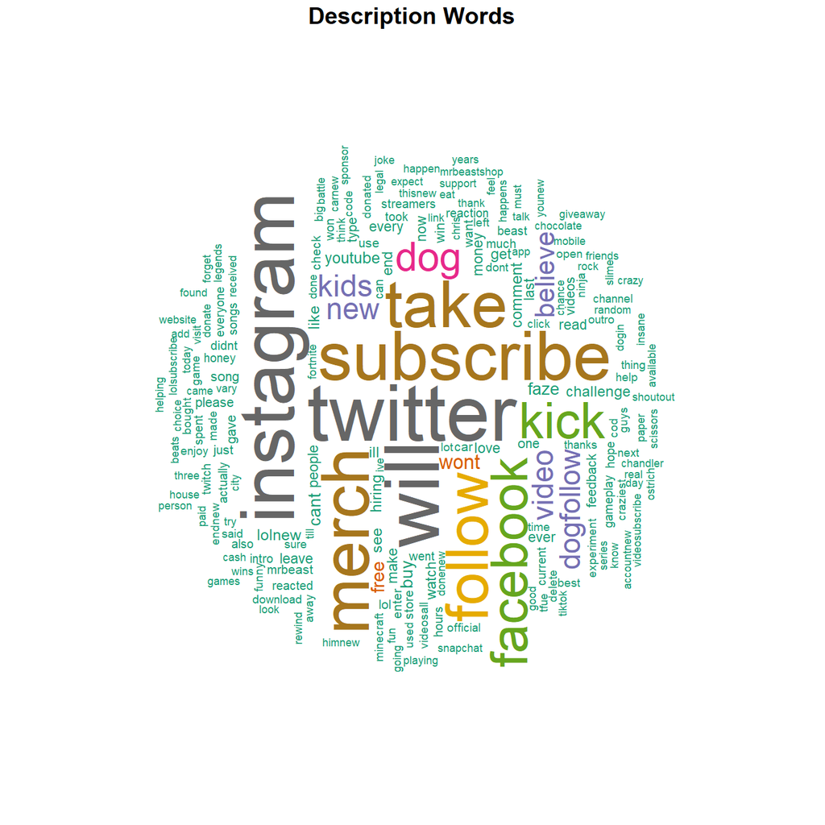

```r
set.seed(124)
wordcloud(words = descriptions_df$word, freq = descriptions_df$freq, min.freq = 1,max.words=200, random.order=FALSE, rot.per=0.55,colors=brewer.pal(8, "Dark2"))
title("Description Words", line = -1, outer = TRUE)
```

Ya’all know the answer to this :p

# Summary

**In this exploratory data analysis we:**

- Found the most successful videos in terms of view count and like-to-view ratio
- Studied the growth of channels over time by analyzing the number of views, likes, comments and their ratios
- Digged into the relationship between video features like duration and user engagement
- Used word clouds to identified keywords used in video titles and descriptions for viewer attraction and social media marketing